# White Wine Quality by Nita Awasthi

#### Wine Quality and Sugar Residual - Mean

```
## Source: local data frame [6 x 4]
##
##   quality sugar_mean sugar_median    n
## 1       3   6.392500         4.60   20
## 2       4   4.628221         2.50  163
## 3       5   7.334969         7.00 1457
## 4       6   6.441606         5.30 2198
## 5       7   5.186477         3.65  880
## 6       8   5.671429         4.30  175
```

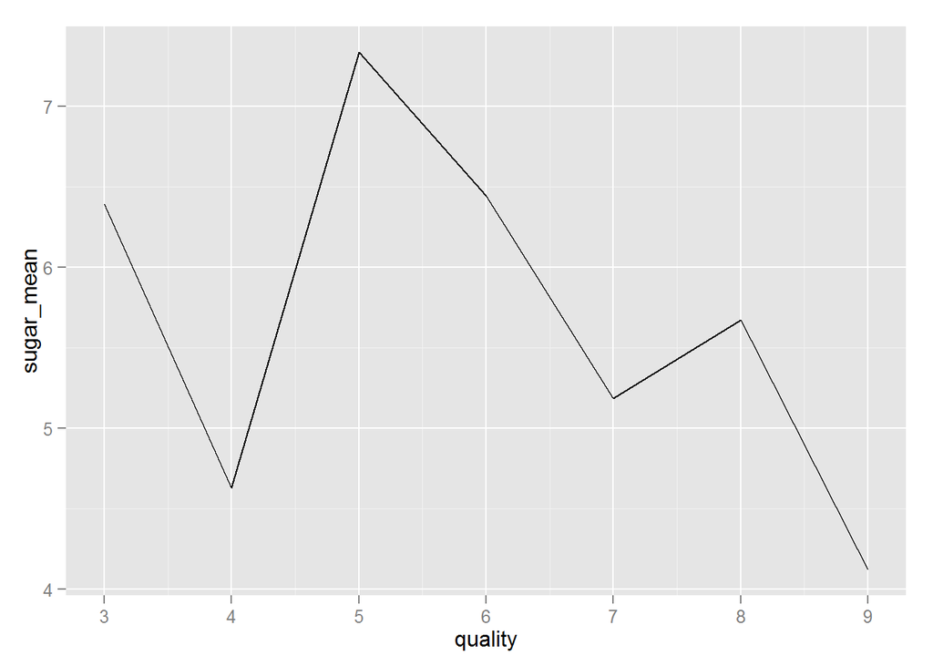

The plot indicates that the better quality white wines have lower sugar residual.

#### Wine Quality and Sugar Residual - boxplot, Quantile

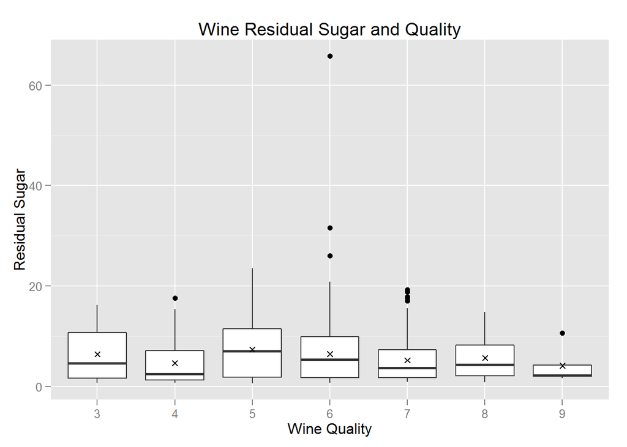

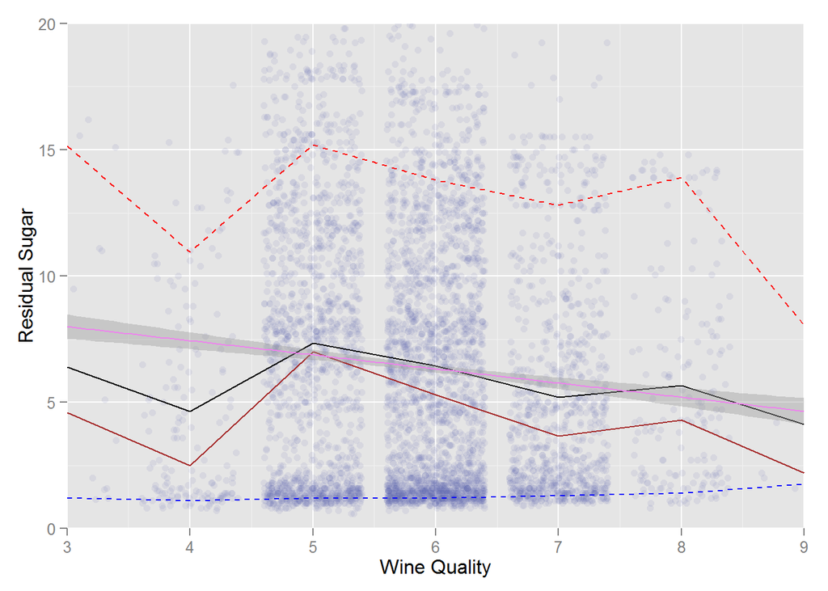

The plot provides the original scatter plot along with the mean , the 3 quantile and coord_cartesian lines.

#### Wine Quality and Sugar Residual - Correlation

```
##
##  Pearson's product-moment correlation
##
## data:  whiteWineQuality$quality and whiteWineQuality$residual.sugar
## t = -6.8603, df = 4896, p-value = 7.724e-12
## alternative hypothesis: true correlation is not equal to 0
## 95 percent confidence interval:
##  -0.12524103 -0.06976101
## sample estimates:
##         cor
## -0.09757683
```

```
##
##  Pearson's product-moment correlation
##
## data:  whiteWineQuality$alcohol and whiteWineQuality$residual.sugar
## t = -35.3209, df = 4896, p-value < 2.2e-16
## alternative hypothesis: true correlation is not equal to 0
## 95 percent confidence interval:
##  -0.4726723 -0.4280267
## sample estimates:
##        cor
## -0.4506312
```

since the correlation result is -0.098, there is no meaningful relationship between residual sugar and wine quality but the coorealtion result of -0.451 indicate some relationship between residual sugar and alcohol level

#### Wine Quality and Density - Mean

```
## Source: local data frame [6 x 4]
##
##   quality density_mean density_median    n
## 1       3    0.9948840       0.994425   20
## 2       4    0.9942767       0.994100  163
## 3       5    0.9952626       0.995300 1457
## 4       6    0.9939613       0.993660 2198
## 5       7    0.9924524       0.991760  880
## 6       8    0.9922359       0.991640  175
```

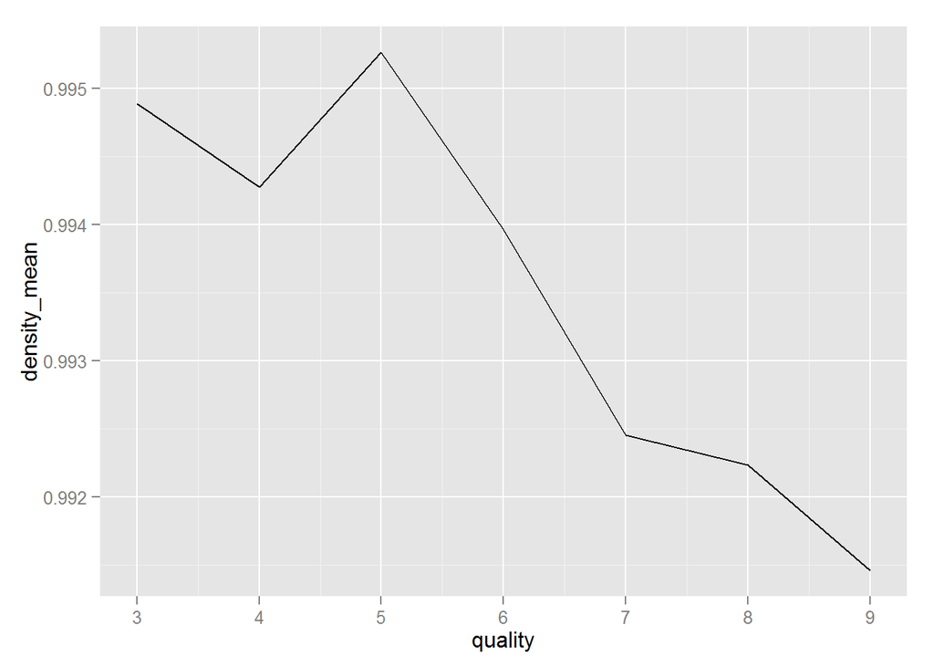

The plot indicates that the better quality white wines have lot lower density. from the qine quality of 5 there is a sharp decline in the denisty.

#### Wine Quality and density - boxplot, Quantile

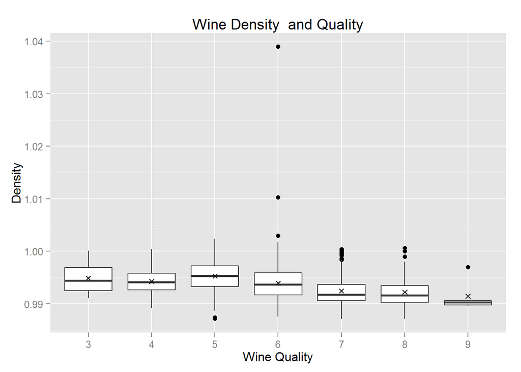

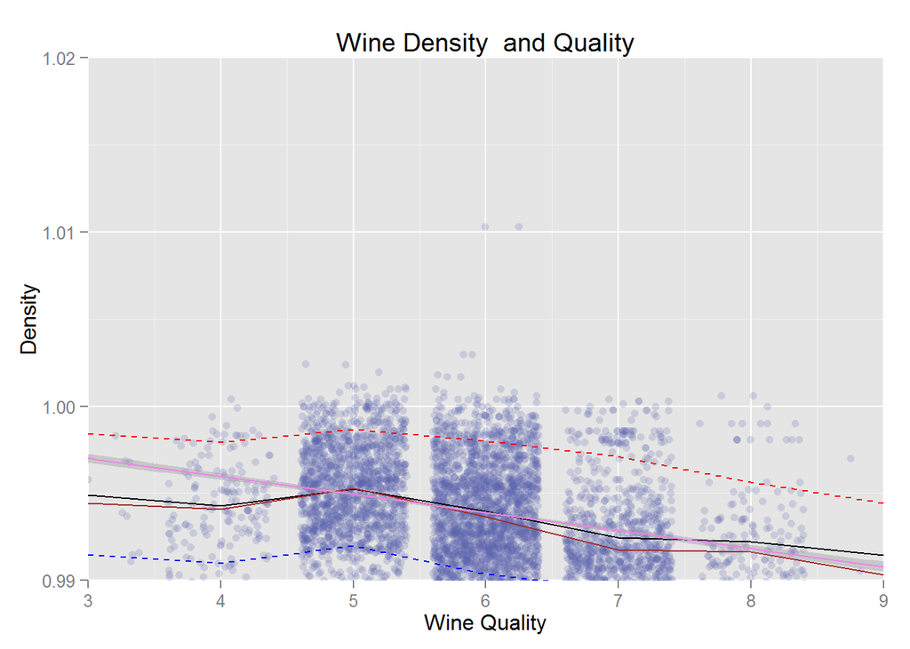

#### Wine Quality and Density - Correlation

```
##
##  Pearson's product-moment correlation
##
## data:  whiteWineQuality$quality and whiteWineQuality$density
## t = -22.5812, df = 4896, p-value < 2.2e-16
## alternative hypothesis: true correlation is not equal to 0
## 95 percent confidence interval:
##  -0.3322718 -0.2815385
## sample estimates:
##        cor
## -0.3071233
```

```
##
##  Pearson's product-moment correlation
##
## data:  whiteWineQuality$alcohol and whiteWineQuality$density
## t = -87.2549, df = 4896, p-value < 2.2e-16
## alternative hypothesis: true correlation is not equal to 0
## 95 percent confidence interval:
##  -0.7908646 -0.7689315
## sample estimates:
##        cor
## -0.7801376
```

since the correlation result is -0.307, there is some relationship between the density and wine quality. Also there is some relationship between density and alcohol levels based on the correlation of -0.7801376

# Bivariate Analysis

### Talk about some of the relationships you observed in this part of the investigation. How did the feature(s) of interest vary with other features in the dataset?

I explored various data sets that seems to have some impact on the wine quality as well as the relationship of different chemical components with each other. Some of the relationship that I explored in this section were:

1. Residual Sugar and alcohol: Based on the previous analysis alcohol level and residual sugar seems to have some influence on the wine quality . I wanted to compare if there was a relation between residual sugar and alcohol level. The plot does seems to indicate that lower alcohol level has more sugar residual.
2. PH and alcohol - The plot indicates that the pH level is consistent and does not seem to indicate any marked change with the levels of alcohol.
3. Density and alcohol - Based on the previous analysis alcohol level and Density seems to have some influence on the wine quality . I wanted to compare if there was a relation between Density and alcohol level. The plot does seems to indicate that lower alcohol level has more density.
4. volatile acidity and wine quality - I wanted to check if the volatile acidity has any impact on the quality of the wine as at too high of levels can lead to an unpleasant, vinegar taste. According to the plot most of the wine have the volatile acidity below 0.4. Some of the medium and low quality wine has volatile acidity higer but none of the highest quality of 9 has volatile acidity higher than 0.4. However wine quality of 8 has some higher levels so this alone might not contribute to the quality of wine.
5. Total sulfur dioxide and free sulfur dioxide - I wanted to explore the relationship between the total and free sulfur dioxide as they were both forms of SO2 and there is visually an almost linear relationship between the two variables.
6. Sulpahtes and the 2 different sulfur dioxides - I wanted to explore the relationship between sulfur chemicals and looking at the plot relationship between Total Sulphur dioxide and sulpahtes and Free sulfur dioxide and sulphates is very similar when appropriate limits and breaks are added.
7. wine quality and alcohol - The privious summary analysis done indicated there was definately some impact on the quality of wine based on the alcohol level. I took the mean and median of the alcohol level and plotted it with the wine quality and the plot indicates that the better quality white wines have higher alcohol levels.
8. Wine quality and density - There is a very distinct correlation ship between the alcohol level and density. Since Alcohol level wine quality indicate that there exists a relationship between then I explored the relationship between the density and wine quality and there does seem to a coorelation between them too. Wine quality higher than 5 show a decrease in density.
9. Wine quality and residual Sugar - The plot seems to indicate lower level residual sugar have higher quality wine. However the correlation numbers does not show it to have meaningful relationship. I will explore it further in the multivariate plots.

### Did you observe any interesting relationships between the other features (not the main feature(s) of interest)?

The interesting features that I observed were that residual sugar, denisty seems to have some impact on alcohol.Higher alcohol level has lower residual sugar and density. Also there doesn’t seem to be enough variation in pH level to indicate any influence in the alcohol level or wine quality. Another interesting observartion was that between the sulphates and 2 types of sulfur dioxide in the wine data seems to have similar relationship. Also, after the wine quality of level 5 there is a sharp increase in the quality of wine in proportion to alcohol level indicating that better quality wine have higher alcohol content. Also the better quality wine have less sugar residual which corresponds to the earlier observation that higher alcohol level has lower residual sugar. The correlation number does not indicate any meaningful relationship between the wine quality and residual sugar so it could be possible that the relationship between the alcohol level and residual sugar influencing this relationship. Observation can also be made in the relationship between density and wine quality. Better quality wine have lower density and higher alcohol level.

# Multivariate Plots Section

#### Wine Quality, alcohol, residual sugar and Density

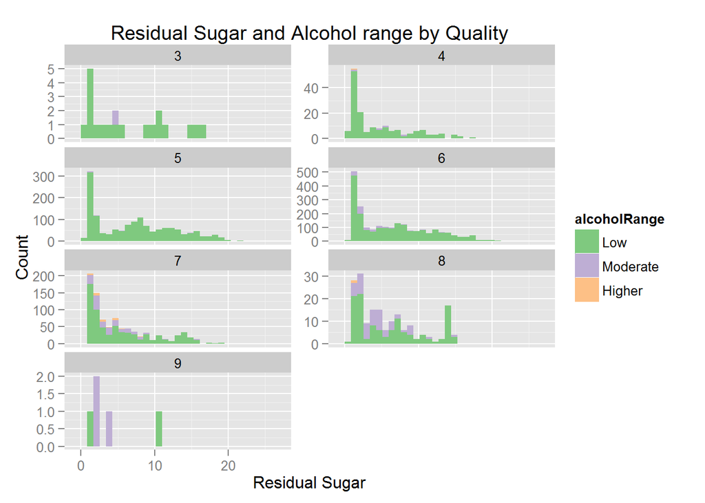

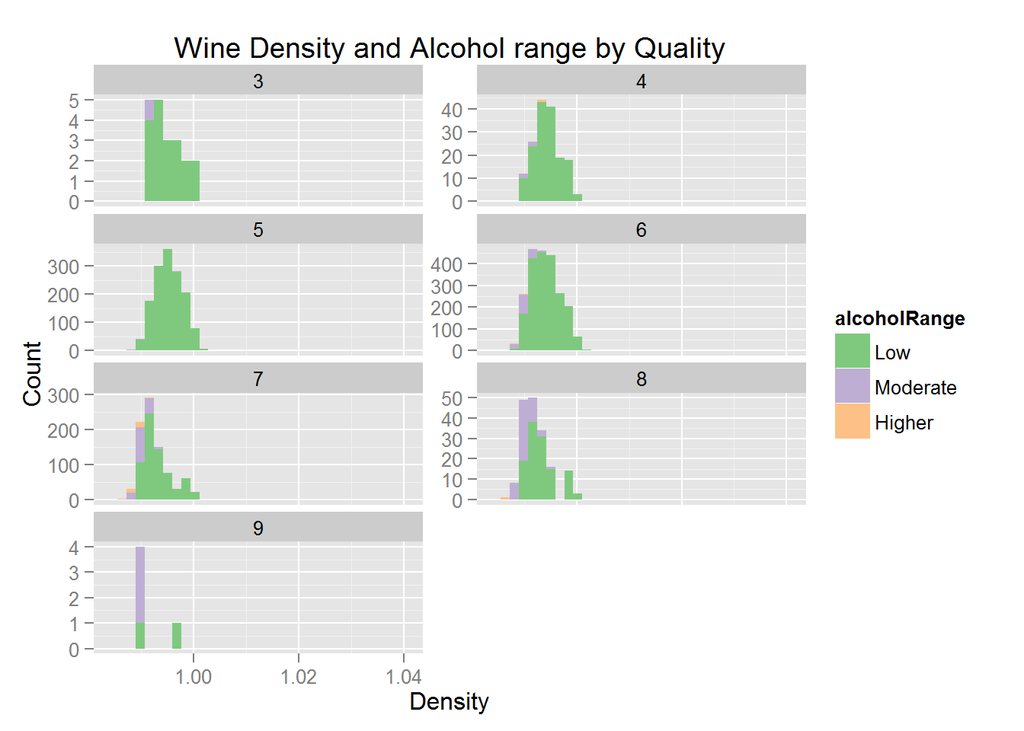

I added a column for alcoholRange based on info that I was able to find on the web. (http://www.realsimple.com/holidays-entertaining/entertaining/food-drink/alcohol-content-wine) I used that into to plot the relationship betwen density and alcohol range by quality and residual sugar and alcohol range by quality.

#### Wine Quality, alcohol, residual sugar

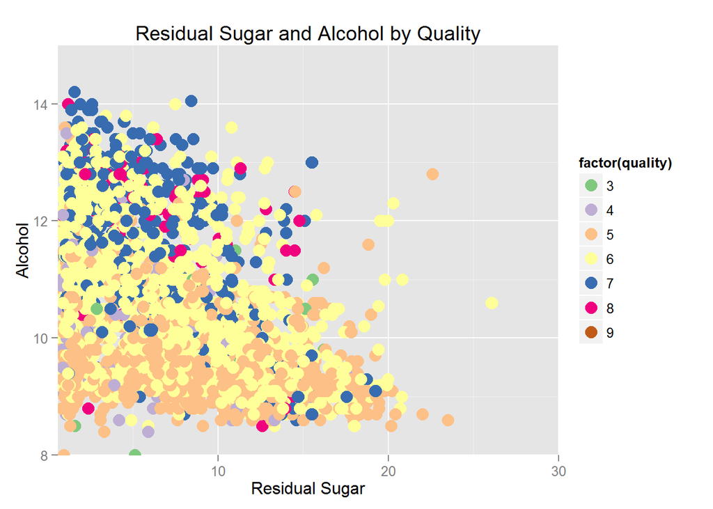

In this plot, there are more wines with high alcohol level and low sugar in the higher quality range than in the lower quality wine.

#### Wine Quality, alcohol and Density

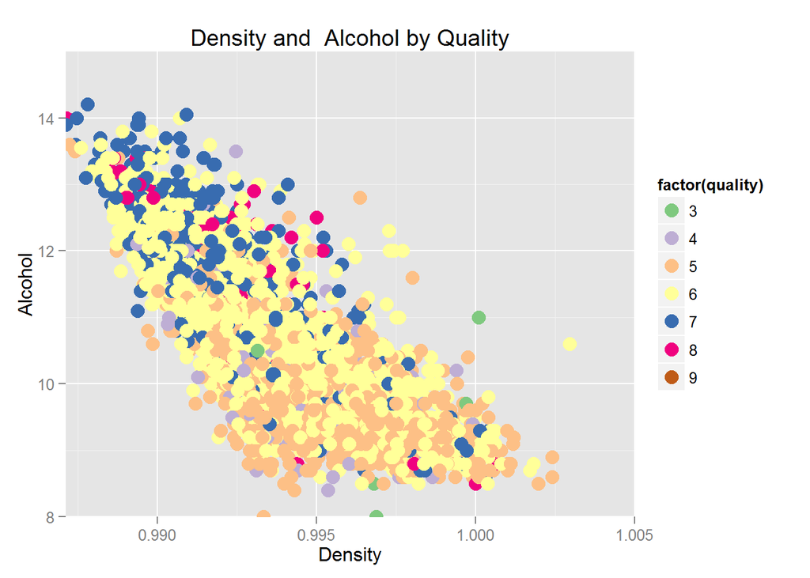

In this plot we can see that higher alcohol wine have lower density and the quality of 7 and 8 seems to have higher concentration in that area. There are few of them in lower range but over all pattern seems to indicate that high alcohol low density is more common in higher quality wines.

# Multivariate Analysis

### Talk about some of the relationships you observed in this part of the investigation. Were there features that strengthened each other in terms of looking at your feature(s) of interest?

I tried to explore the relationships between alcohol, wine quality, density and residual Sugar. I also, added a column for alcoholRange based on info that I was able to find on the web. (http://www.realsimple.com/holidays-entertaining/entertaining/food-drink/alcohol-content-wine) I used that to plot the relationship betwen density and alcohol range by quality and residual sugar and alcohol range by quality. The facet plots that I was able to create with this variable seem to indicate that better quality of wine has higher percentage of higher alcohol level and and less density and less residual sugar. However the range of alcohol categorized indicates that there is not enough data in the higher range to clearly show the relationship. I added the scatterplot with same relationship but using actual alcohol level values. This seems to give a better indication of the relationship between these variables that I explored. In the plot for alcohol, residual sugar and wine quality there are more wines with high alcohol level and low sugar in the higher quality range than in the lower quality wine. Similar observations can be made for the scatter plot for alcohol, denisty and quality. In this plot we can see that higher alcohol content wine have lower density and the quality of 7 - 8 seems to have higher concentration in that area. There are few of them in lower range but over all pattern seems to indicate that high alcohol and low density is more common in higher quality wines.

### Were there any interesting or surprising interactions between features?

The relationship between alcohol, density and quality seems to be more clear than the one between sugar residual and alcohol level and quality. There are only higher alcohol level wine with low denisty and no wine with lower alcohol level and low denisty which is not the case for residual sugar there are higher alcohol content wine with low sugar as well as low alcohol content wine with low sugar.

But both higher alcohol level wine doesn’t have high density nor higher residual sugar. Higher wine quality seems to be concentrated on more on higher alcohol level for both relationship.

# Final Plots and Summary

### Plot One

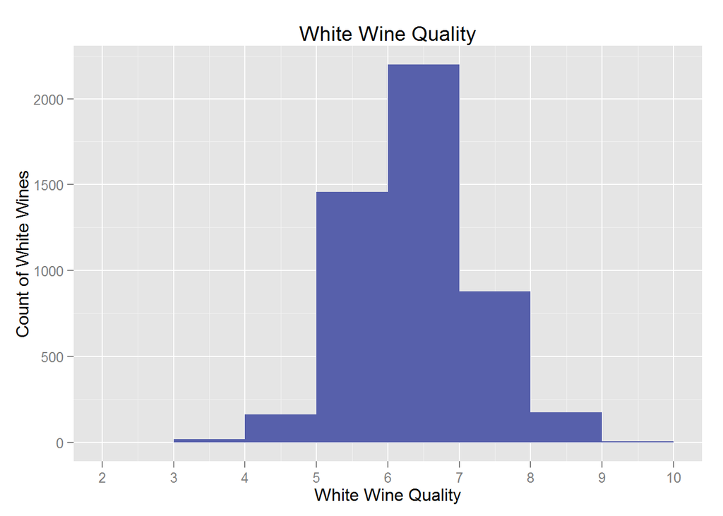

### Description One

The wine quality in this data ranges from 3 to 9 with most wine falling in the mid range quality of 5 - 6 followed by a slightly higher level of 7. The number of wines falling in the range below 5 and above 7 is almost same and very few in lowest and uppermost limit of 3 and 9.

### Plot Two

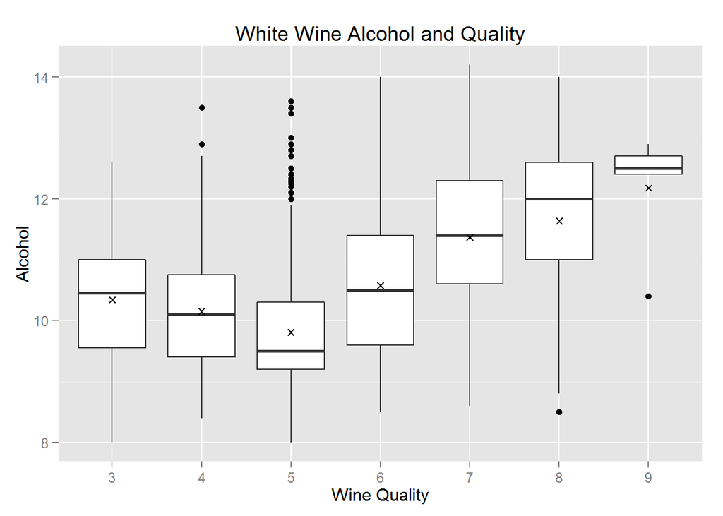

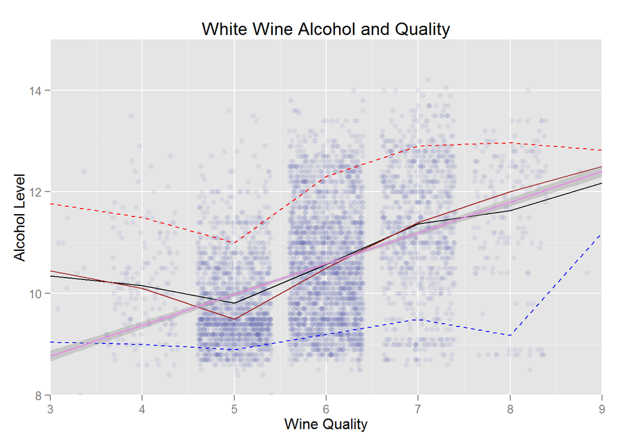

### Description Two

The mean of the alcohol level with the wine quality in the plot indicates that the better quality white wines have higher alcohol levels.

### Plot Three

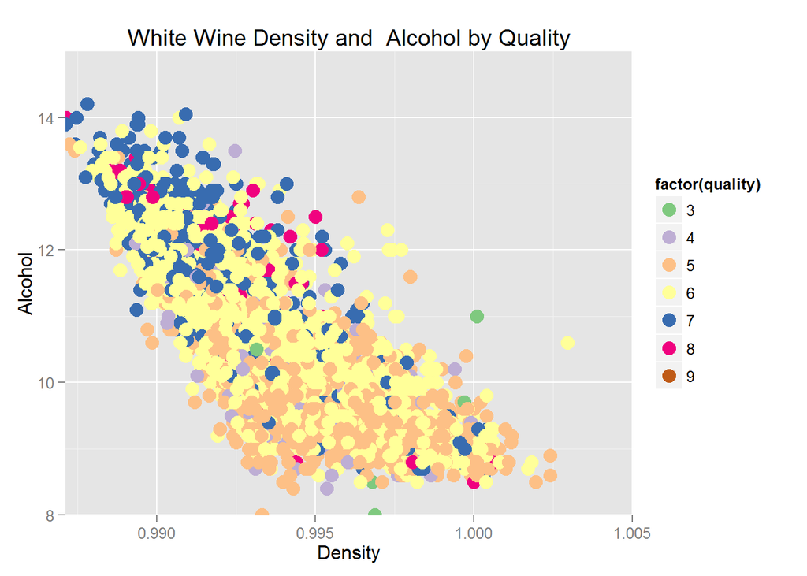

### Description Three

In this plot we can see that higher alcohol content wine have lower density and the quality of 7 and 8 seems to have higher concentration in that area. There are few of them in lower range but overall pattern seems to indicate that high alcohol and low density is more common in higher quality wines.

# Reflection

I started out my exploration with viewing the summary of the data for the white wine quality and different variables in the dataset. The next step involved plotting the quality and other variables to check out their distribution and pick some of the the variables for further exploration. For the two variable plots I tried to explore various relationship some with the quality and some with alcohol level and couple of two similar chemical variables. Based on the relationship observed in the two variables plots I picked alcohol , density, residual sugar, and quality to futher explore their relationship and determine its influence on white wine quality.

My observations:

1. The better quality wine seems to have higher alcohol content.
2. The higher alcohol content wine always have lower density.
3. The higher alcohol content does not have high residual sugar.
4. High alcohol content and low density have better concentration of high wine quality.
5. High alcohol content and low sugar also have slightly better concentration of high wine quality.
6. pH levels does not seem to have any impact on the wine quality.
7. The relationship and distribution between total sulfur dioxide , free sulfur dioxide and sulphates are similar in distribution.
8. Most of the wine have volatile acidity of 0.4. None of the wine of the highest quality has it above this level.

In conclusion, there seems to be a relationship that does impact the quality of wine which is that of alcohol content and density. High alcohol content will always have lower density than lower alcohol content wine and they have better concentration of higher quality wine in this dataset.